# Humanities Network Analysis

John R. Ladd, jrladd.com/slides/network-data

`spacebar` to go to the next slide, `esc`/menu to navigate

# What is a network?

- A mathematical structure, a visual form, an operative metaphor, a data analysis method
- A network is made up of:
  - Entities: node, vertex, actor
  - Relationships: edge, link, tie
  - In the humanities, we most often say nodes and edges

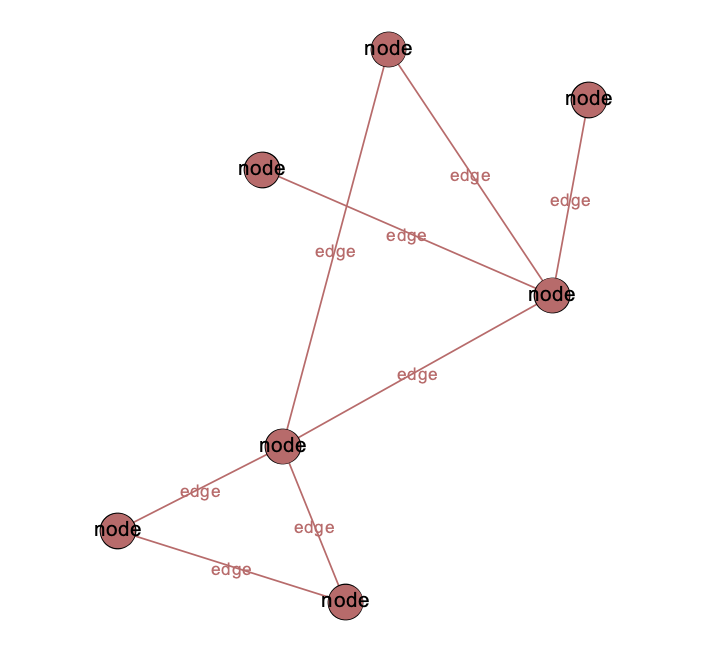

# Where did network analysis come from?

[figure not shown]

Image credit: Ahnert et al., *The Network Turn* Chapter 4

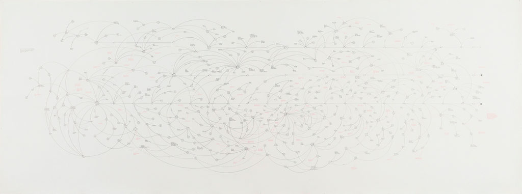

Mark Lombardi, BCCI-ICIC & FAB, 1972-91 (4th version)

# What can we learn from networks?

## Cross-disciplinary formations

- Social Networks
- Biological Networks
- Information Networks
- Technological Networks

## Scale-free networks and the small world

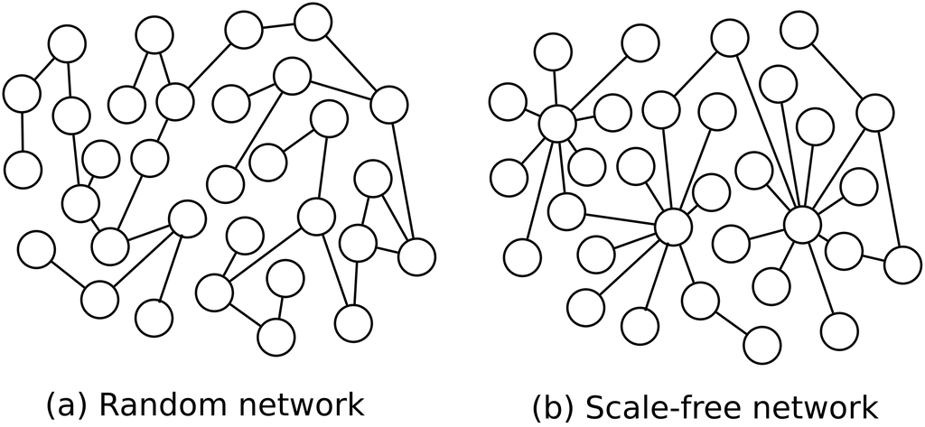

## Types of humanities network projects

- Visualization
- Statistics and Computation
- Conceptual and Theoretical

## Why turn to networks?

- Community structure
- Behavior
- Transmission of Information

## Example Research Questions

- What was the role of women in underground Protestant communities during the reign of Mary I? (Ahnert & Ahnert 2015)
- Which books and readers were most prominent in Modernist literary reception at *Shakespeare and Company*? (Antoniak et al. 2024)
- “First, how were publications by dramatists and other poets situated within the larger print marketplace? Second, how did paratextual criticism change over time between 1660 and 1700? And third, how did women’s contributions differ from men’s?” (Gavin 2016)

# How do we collect network data?

## Edge Table & Node Table

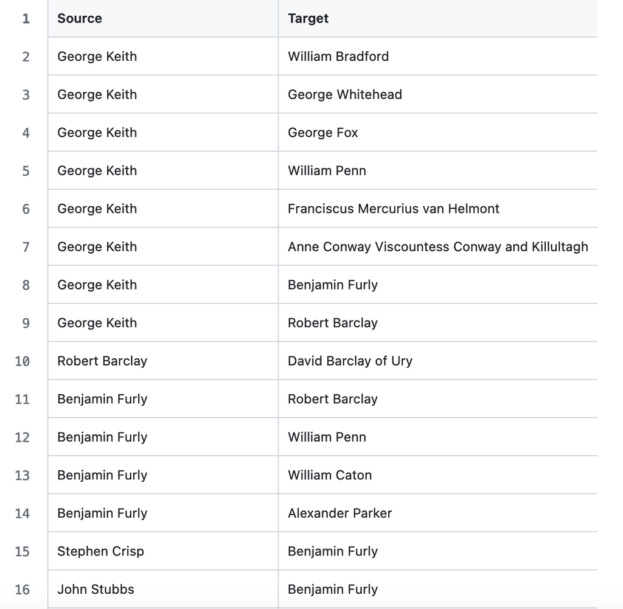

Edge table

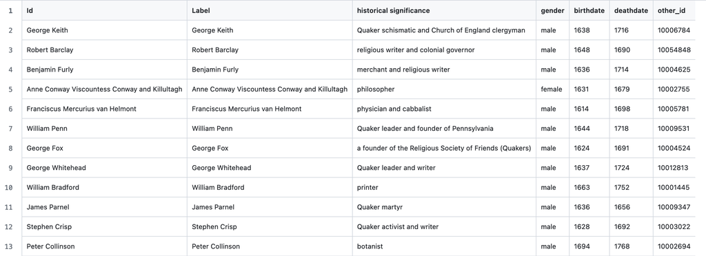

Node table

[figure not shown]

Image credit: geeksforgeeks.com

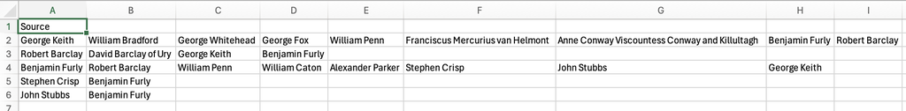

Adjacency List

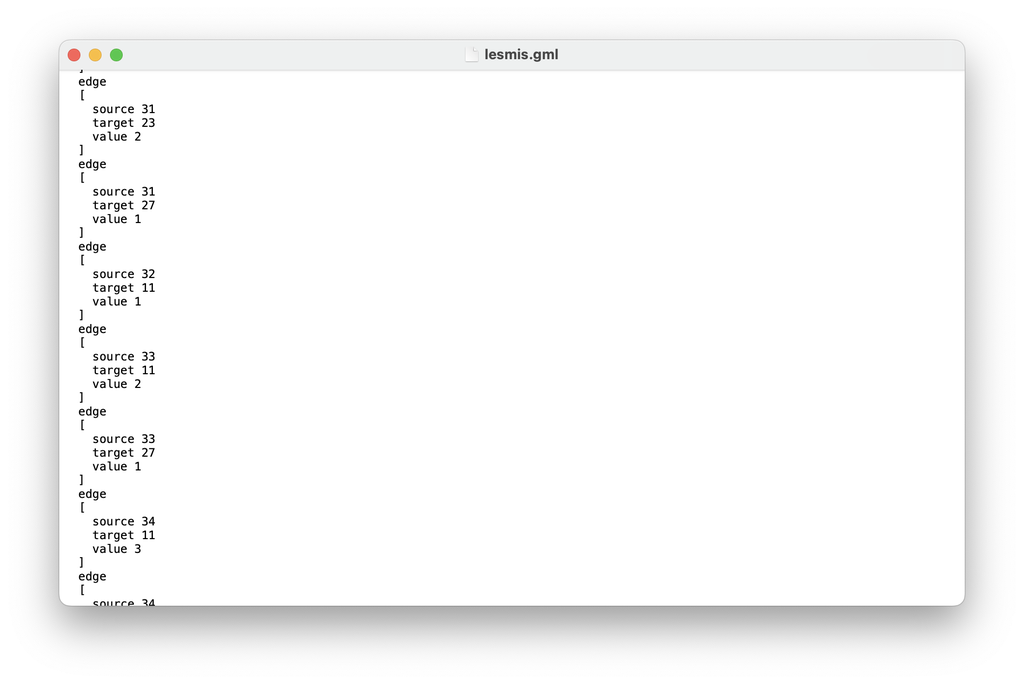

Custom formats: .gml, .graphml, JSON, GEXF, Pajek

## What We’ll Explore Together

- Collect and understand network data
- Visualize data as node-link diagrams
- Basic data analysis with networks

# Additional Resources

- Online Network textbook: https://jrladd.com/networks
- Books to Read (both open access):
  - [*Networks, Crowds, and Markets*](https://www.cs.cornell.edu/home/kleinber/networks-book/) by Easley & Kleinberg
  - [*The Network Turn*](https://doi.org/10.1017/9781108866804) by Ahnert, Ahnert, Coleman, & Weingart
- Technical Tutorials
  - Part 3: https://bit.ly/network_workshop
  - [Programming Historian lesson on network analysis](https://programminghistorian.org/en/lessons/exploring-and-analyzing-network-data-with-python)